# Ch04 Lab tidy Classification

Bruce Hartman

University of St. Francis

2026-09-09 Revised 2026-10-16T08:38:29

Abstract

We will work the Ch04 Lab on classification, from the textbook.

# Introduction

We will work the Ch04 Lab on classification, from the textbook.

# Packages

First we load the packages we will use.

```r
library(ISLR2) #package contains the data files
library(FNN)
library(mbadtools, quietly=TRUE) # tools for mbad courses
```

# Acquire the Data

Our data is in the `ISLR2` package. It is called `Smarket`, and contains daily percentage returns for the S&P 500 stock index between 2001 and 2005.

```r
# The data is in the ISLR2 package
data(Smarket)
Smarket %>% skim
```

```
── Data Summary ────────────────────────
                           Values
Name                       Piped data
Number of rows             1250
Number of columns          9
_______________________
Column type frequency:
  factor                   1
  numeric                  8
________________________
Group variables            None
```

|  | skim_variable | n_missing | complete_rate | ordered | n_unique | top_counts |
| --- | --- | --- | --- | --- | --- | --- |
| 1 | Direction | 0 | 1 | FALSE | 2 | Up: 648, Dow: 602 |

|  | skim_variable | n_missing | complete_rate | mean | sd | p0 | p25 | p50 | p75 | p100 | hist |
| --- | --- | --- | --- | --- | --- | --- | --- | --- | --- | --- | --- |
| 1 | Year | 0 | 1 | 2003.0160000 | 1.4090182 | 2001.00000 | 2002.0000 | 2003.00000 | 2004.000000 | 2005.00000 | ▇▇▇▇▇ |
| 2 | Lag1 | 0 | 1 | 0.0038344 | 1.1362988 | -4.92200 | -0.6395 | 0.03900 | 0.596750 | 5.73300 | ▁▃▇▁▁ |
| 3 | Lag2 | 0 | 1 | 0.0039192 | 1.1362803 | -4.92200 | -0.6395 | 0.03900 | 0.596750 | 5.73300 | ▁▃▇▁▁ |
| 4 | Lag3 | 0 | 1 | 0.0017160 | 1.1387030 | -4.92200 | -0.6400 | 0.03850 | 0.596750 | 5.73300 | ▁▃▇▁▁ |
| 5 | Lag4 | 0 | 1 | 0.0016360 | 1.1387737 | -4.92200 | -0.6400 | 0.03850 | 0.596750 | 5.73300 | ▁▃▇▁▁ |
| 6 | Lag5 | 0 | 1 | 0.0056096 | 1.1475502 | -4.92200 | -0.6400 | 0.03850 | 0.597000 | 5.73300 | ▁▃▇▁▁ |
| 7 | Volume | 0 | 1 | 1.4783050 | 0.3603571 | 0.35607 | 1.2574 | 1.42295 | 1.641675 | 3.15247 | ▁▇▅▁▁ |
| 8 | Today | 0 | 1 | 0.0031384 | 1.1363341 | -4.92200 | -0.6395 | 0.03850 | 0.596750 | 5.73300 | ▁▃▇▁▁ |

In the data we have today’s percentage return, Today, and five lags. Each lag represents the rate of return for one to five days previous. Since stack market data is a time series, it would be reasonable that recent values might depend on the older (lagged) values. However, because of this autocorrelation of values, the assumptions of ordinary Multiple Linear Regression are violated– there is correlation with time of Today’s percentage return.

We are also given the Volume of shares traded in billions, which might influence today’s percentage return. And finally, we have a factor or dummy variable indicating the direction of movement of the return, called Direction. It has values of Up or Down.

# Data Description

A pairs plot may show us some relations between the columns.

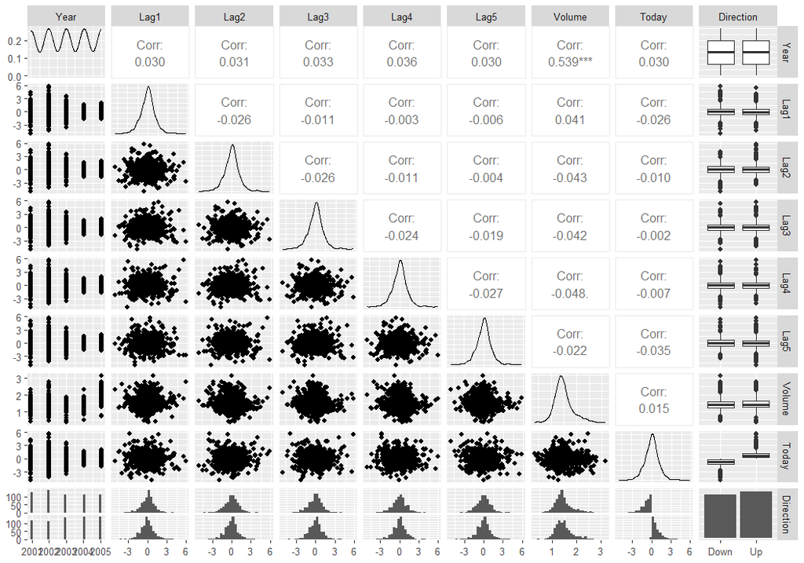

```r
ggpairs(Smarket, progress=F) #uses package GGAlly
```

Most of the pairs plots look like blobs. The highest correlation is with Year and Volume, which only says that Volume is increasing over the years, a well-known fact about the stock market. We can show that with a plot of Volume against time in days. Of course because of weekends and holidays, there is not trading every day. So the days are consecutive open days, not calendar days. The graph shows the slight increasing trend.

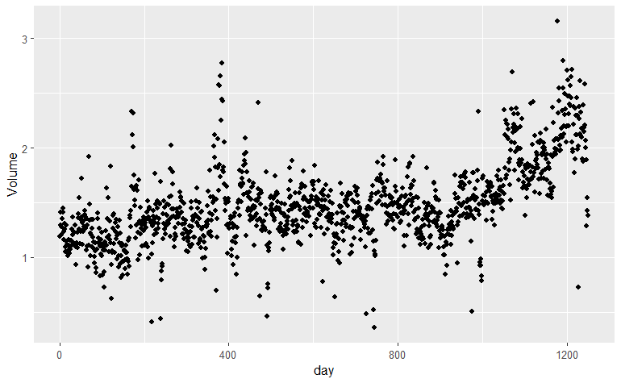

```r
ggplot(Smarket %>% mutate(day=1:nrow(Smarket))) +
  geom_point(aes(x=day,y=Volume))
```

# What’s next?

Our goal is to try to predict Direction using the other data. We can see how Direction is coded like this.

```r
Smarket %>% pull(Direction) %>% contrasts
```

```
     Up
Down  0
Up    1
```

Because Direction is a factor, here a binary variable, with Down coded as 0 and Up coded as 1, we need to use a classification technique. The three we will present are

- Logistic Regression
- Linear Discriminant Analysis, and
- K-Nearest Neighbors classification using the `FNN` package.

# Validating a model

We want to know how well each model will predict the direction of the S&P500 each day. As a business fact, we want to predict the future, not the past. So we need to assess how the different models work on more recent data using only past data. This is a key decision that the analyst must make.

Sometimes we can do this by randomly sampling the data. However, since this is time-series data, that would make no sense. Here we will separate the data into a training dataset and a test dataset; the test data will be year 2005, and the training data will be all previous data. We will then create our models using the training data. Finally we will predict the model results on the 2005 test data. Estimates of error on the test data should be comparable for the three models.

# Data Preparation

Here is how to separate the data into training and test data. we use a proportion to exactly split at 2004/2005 boundary.

```r
set.seed(2026)
split <- initial_time_split(Smarket, prop = .799)
train_data <- training(split)
test_data  <- testing(split)
dim(train_data)
```

```
[1] 998   9
```

```r
dim(test_data)
```

```
[1] 252   9
```

```r
# if we need folds for parameter tuning
folds      <- vfold_cv(train_data, v = 5)
```

Notice that all the data is in one of the two datasets.

# Recipe

We need the recipe for our classification problem.

We found earlier that only 2 lags works well.

```r
smarket_recipe <- recipe(Direction ~ Lag1 + Lag2,
                         data = train_data)

rec_basic <- smarket_recipe

rec_range <- smarket_recipe %>%
  step_range(all_numeric_predictors())
```

# Model Specification

Four models are specified.

- logistic regression using `glm`
- LDA using `MASS`
- QDA using `MASS`
- KNN using `kknn`; different from basic example

```r
# logistic
logreg_spec <- logistic_reg() |>
  set_engine("glm") |>
  translate()
# LDA
library(discrim)
lda_spec <- discrim_linear() |>
  set_engine("MASS") |>
  translate()
# QDA
qda_spec <- discrim_quad() |>
  set_engine("MASS") |>
  translate()
# KNN
library(kknn)
# Parsnip changes the default range for neighbors to c(1, 15) and dist_power to c(1/10, 2).
knn_spec <- nearest_neighbor(
  neighbors = tune(),
  weight_func = tune(),
  dist_power = tune()
) |>
  set_engine("kknn") |>
  set_mode("classification") |>
  translate()
```

# Workflow Set

There are 2 preprocessing states, basic and ranged data; and four models.

```r
wf_set <- workflow_set(
  preproc = list(rec_basic, rec_range),
  models  = list(log = logreg_spec,
                 lda = lda_spec,
                 qda = qda_spec,
                 knn = knn_spec),
  cross = TRUE # Cross-combines all recipes with all models
)
```

# Fit All Workflows to Resamples

```r
set.seed(123)
tictoc::tic()
# Fit every workflow in the set across all CV folds
wf_results <- wf_set %>%
  workflow_map("tune_grid", resamples = folds)
tictoc::toc()
```

```
44.7 sec elapsed
```

```r
wf_results
```

| wflow_id | info | option | result |
| --- | --- | --- | --- |
| recipe_1_log |  |  |  |
| recipe_1_lda |  |  |  |
| recipe_1_qda |  |  |  |
| recipe_1_knn |  |  |  |
| recipe_2_log |  |  |  |
| recipe_2_lda |  |  |  |
| recipe_2_qda |  |  |  |
| recipe_2_knn |  |  |  |

# Rank and Compare Model Performance

```r
collect_metrics(wf_results)
```

| wflow_id | .config | preproc | model | .metric | .estimator | mean | n | std_err |
| --- | --- | --- | --- | --- | --- | --- | --- | --- |
| recipe_1_log | pre0_mod0_post0 | recipe | logistic_reg | accuracy | binary | 0.5170151 | 5 | 0.0140829211 |
| recipe_1_log | pre0_mod0_post0 | recipe | logistic_reg | brier_class | binary | 0.2507920 | 5 | 0.0006027074 |
| recipe_1_log | pre0_mod0_post0 | recipe | logistic_reg | roc_auc | binary | 0.5108992 | 5 | 0.0167151794 |
| recipe_1_lda | pre0_mod0_post0 | recipe | discrim_linear | accuracy | binary | 0.5140050 | 5 | 0.0140693593 |
| recipe_1_lda | pre0_mod0_post0 | recipe | discrim_linear | brier_class | binary | 0.2507872 | 5 | 0.0006007315 |
| recipe_1_lda | pre0_mod0_post0 | recipe | discrim_linear | roc_auc | binary | 0.5108791 | 5 | 0.0167051019 |
| recipe_1_qda | pre0_mod0_post0 | recipe | discrim_quad | accuracy | binary | 0.4889548 | 5 | 0.0121721406 |
| recipe_1_qda | pre0_mod0_post0 | recipe | discrim_quad | brier_class | binary | 0.2545235 | 5 | 0.0011219905 |
| recipe_1_qda | pre0_mod0_post0 | recipe | discrim_quad | roc_auc | binary | 0.4771401 | 5 | 0.0127405119 |
| recipe_1_knn | pre0_mod01_post0 | recipe | nearest_neighbor | accuracy | binary | 0.5120101 | 5 | 0.0141545689 |

[output cut: 68 more lines]

```r
# Rank models by performance (e.g., RMSE)
rank_results(wf_results, rank_metric = "accuracy",
             select_best = TRUE) %>%
  filter(.metric=="accuracy")
```

| wflow_id | .config | .metric | mean | std_err | n | preprocessor | model | rank |
| --- | --- | --- | --- | --- | --- | --- | --- | --- |
| recipe_1_log | pre0_mod0_post0 | accuracy | 0.5170151 | 0.01408292 | 5 | recipe | logistic_reg | 1 |
| recipe_2_log | pre0_mod0_post0 | accuracy | 0.5170151 | 0.01408292 | 5 | recipe | logistic_reg | 2 |
| recipe_2_lda | pre0_mod0_post0 | accuracy | 0.5140050 | 0.01406936 | 5 | recipe | discrim_linear | 3 |
| recipe_1_lda | pre0_mod0_post0 | accuracy | 0.5140050 | 0.01406936 | 5 | recipe | discrim_linear | 4 |
| recipe_1_knn | pre0_mod01_post0 | accuracy | 0.5120101 | 0.01415457 | 5 | recipe | nearest_neighbor | 5 |
| recipe_2_knn | pre0_mod01_post0 | accuracy | 0.5120101 | 0.01415457 | 5 | recipe | nearest_neighbor | 6 |
| recipe_2_qda | pre0_mod0_post0 | accuracy | 0.4889548 | 0.01217214 | 5 | recipe | discrim_quad | 7 |
| recipe_1_qda | pre0_mod0_post0 | accuracy | 0.4889548 | 0.01217214 | 5 | recipe | discrim_quad | 8 |

# Plot performance comparisons visually

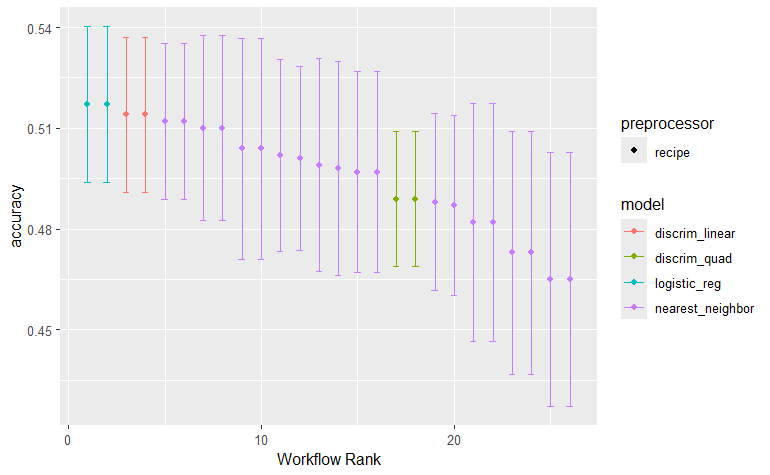

```r
autoplot(wf_results, metric = "accuracy")
```

Accuracy results ranked top 8:

```r
rank_results(wf_results, rank_metric = "accuracy",
             select_best = TRUE) %>%
  filter(.metric=="accuracy") %>% slice(1:8)
```

| wflow_id | .config | .metric | mean | std_err | n | preprocessor | model | rank |
| --- | --- | --- | --- | --- | --- | --- | --- | --- |
| recipe_1_log | pre0_mod0_post0 | accuracy | 0.5170151 | 0.01408292 | 5 | recipe | logistic_reg | 1 |
| recipe_2_log | pre0_mod0_post0 | accuracy | 0.5170151 | 0.01408292 | 5 | recipe | logistic_reg | 2 |
| recipe_2_lda | pre0_mod0_post0 | accuracy | 0.5140050 | 0.01406936 | 5 | recipe | discrim_linear | 3 |
| recipe_1_lda | pre0_mod0_post0 | accuracy | 0.5140050 | 0.01406936 | 5 | recipe | discrim_linear | 4 |
| recipe_1_knn | pre0_mod01_post0 | accuracy | 0.5120101 | 0.01415457 | 5 | recipe | nearest_neighbor | 5 |
| recipe_2_knn | pre0_mod01_post0 | accuracy | 0.5120101 | 0.01415457 | 5 | recipe | nearest_neighbor | 6 |
| recipe_2_qda | pre0_mod0_post0 | accuracy | 0.4889548 | 0.01217214 | 5 | recipe | discrim_quad | 7 |
| recipe_1_qda | pre0_mod0_post0 | accuracy | 0.4889548 | 0.01217214 | 5 | recipe | discrim_quad | 8 |

None of the models did too well on accuracy; the best was only 52%. `recipe_1` and `recipe_2` gave the same answers in all cases.

```r
bartlett.test(Lag1 ~ Direction, data = train_data)
```

```
    Bartlett test of homogeneity of variances

data:  Lag1 by Direction
Bartlett's K-squared = 0.0058648, df = 1, p-value = 0.939
```

```r
bartlett.test(Lag2 ~ Direction, data = train_data)
```

```
    Bartlett test of homogeneity of variances

data:  Lag2 by Direction
Bartlett's K-squared = 0.11164, df = 1, p-value = 0.7383
```

# Extract Best Fit

```r
# Extract a specific workflow (e.g., "recipe_1_knn")
best_wf <- extract_workflow(wf_results, id = "recipe_1_knn")
best_wf
```

```
══ Workflow ═════════════════════════════════════════════════════════
Preprocessor: Recipe
Model: nearest_neighbor()

── Preprocessor ─────────────────────────────────────────────────────
0 Recipe Steps

── Model ────────────────────────────────────────────────────────────
K-Nearest Neighbor Model Specification (classification)

Main Arguments:
  neighbors = tune()
  weight_func = tune()
  dist_power = tune()

Computational engine: kknn

Model fit template:
kknn::train.kknn(formula = missing_arg(), data = missing_arg(),
    ks = min_rows(tune(), data, 5), kernel = tune(), distance = tune())
```

```r
## S3 method for class 'model_spec'
extract_parameter_set_dials(best_wf)
extract_parameter_dials(best_wf, "neighbors")
# Extract the best hyperparameters for that specific workflow
best_params <- select_best(
  extract_workflow_set_result(wf_results, id = "recipe_1_knn"),
  metric = "accuracy"
)
best_params
```

| neighbors | weight_func | dist_power | .config |
| --- | --- | --- | --- |
| 1 | gaussian | 0.9444444 | pre0_mod01_post0 |

# Finalize

```r
# Finalize the workflow with best hyperparameter values
final_wf <- finalize_workflow(best_wf, best_params)

# Fit on 100% of data and evaluate on test_data
tictoc::tic()
final_fit <- last_fit(final_wf, split)
tictoc::toc()
```

```
0.81 sec elapsed
```

```r
# View test set metrics (accuracy)
collect_metrics(final_fit) %>% filter(.metric=="accuracy")
```

| .metric | .estimator | .estimate | .config |
| --- | --- | --- | --- |
| accuracy | binary | 0.468254 | pre0_mod0_post0 |

# Predictions

Make predictions for the test data. The accuracy is only 47% on all data.

```r
FT = collect_predictions(final_fit, summarize=TRUE) %>%
  arrange(.row) %>%
  select(Direction, .pred_class) %>%
  conf_mat(Direction, .pred_class)
FT
```

```
          Truth
Prediction Down Up
      Down   40 63
      Up     71 78
```

```r
FT %>% summary %>% filter(.metric=="accuracy")
```

| .metric | .estimator | .estimate |
| --- | --- | --- |
| accuracy | binary | 0.468254 |

On the test data, the best model is wrong more than it is right!! 47%

# Old Modeling

```r
best_params
```

| neighbors | weight_func | dist_power | .config |
| --- | --- | --- | --- |
| 1 | gaussian | 0.9444444 | pre0_mod01_post0 |

```r
fit.kknn <- kknn(Direction ~ Lag1+ Lag2,
                 train_data, test_data,
                 k = best_params$neighbors,
                 distance = best_params$dist_power,
                 kernel = best_params$weight_func)
# get prior
prior = split %>% data.frame %>%
  filter(Direction=="Up") %>%
  count %>% pull(n) / nrow(split %>% data.frame)
prior
```

```
[1] 0.508016
```

```r
# get probabilities
pred.kknn = case_when( fit.kknn$prob[,"Up"] > prior ~ "Up",
                       .default = "Down")
# confusion mtx
KT = data.frame(Direction = test_data$Direction,
               .pred = factor(pred.kknn) ) %>%
  conf_mat(Direction, .pred)
KT
```

```
          Truth
Prediction Down Up
      Down   40 63
      Up     71 78
```

```r
KT %>% summary %>% filter(.metric=="accuracy")
```

| .metric | .estimator | .estimate |
| --- | --- | --- |
| accuracy | binary | 0.468254 |

# Compare with Workflow

```r
tibble(
  Workflow_accuracy = FT %>% summary %>%
    slice(1) %>% pull(.estimate),
  Standard_accuracy = KT %>% summary %>%
    slice(1) %>% pull(.estimate)
)
```

| Workflow_accuracy | Standard_accuracy |
| --- | --- |
| 0.468254 | 0.468254 |

# Try different k

Just for fun we run `kknn` again choosing naively the parameters, iterating over k.

```r
best_params
```

| neighbors | weight_func | dist_power | .config |
| --- | --- | --- | --- |
| 1 | gaussian | 0.9444444 | pre0_mod01_post0 |

```r
for (k in 1:6) {
  fit.kknn3 <- kknn(Direction ~ Lag1+ Lag2,
                   train_data, test_data,
                   k = k,
                   distance = 2, # default, euclidean
                   kernel = "rectangular" # std unweighted
  )
  # get prior

  # get probabilities
  pred.kknn3 = case_when( fit.kknn3$prob[,"Up"] > prior ~ "Up",
                         .default = "Down")
  # confusion mtx
  KT3 = data.frame(Direction = test_data$Direction,
                 .pred = factor(pred.kknn3) ) %>%
    conf_mat(Direction, .pred)
  KT3
  cat("\nk = ", k, " accuracy = ",
  KT3 %>% summary %>%
    filter(.metric=="accuracy") %>%
    pull(.estimate),
  "\n")
}
```

```
k =  1  accuracy =  0.5

k =  2  accuracy =  0.484127

k =  3  accuracy =  0.531746

k =  4  accuracy =  0.515873

k =  5  accuracy =  0.484127

k =  6  accuracy =  0.4960317
```

3 neighbors comes up best.

# Discussion and Conclusion

We have tried four different classification methods on the `Smarket` data, using as drivers only the first two lags.

We used a workflow from `tidymodels` and `workflowsets` to perform the process.

We then ran the `kknn` model with those parameters on its own, the old way, and obtained almost the same accuracy. This model considers the training and test data all at once, producing classification and probabilities on the test data in one step.

We also tried iterating over the number of neighbors, choosing the other parameters naively as euclidean distance and a rectangular (standard unweighted) kernel. Here, 3 neighbors came out best in accuracy with 53%.

# References

1. James, Gareth; Witten, Daniela; Hastie, Trevor; Tibshirani, Robert. (2013) An Introduction to Statistical Learning with Applications in R. *Springer Texts in Statistics* eds. Casella, Fienberg, and Olkin. New York, Springer, 2013. [1](http://www.statlearning.com/), retrieved October 20, 2021.
2. Sirohi, Kshitiz (2018) K-nearest Neighbors Algorithm with Examples in R (Simply Explained knn). *Towards Data Science*, September 30, 2018. [2](https://towardsdatascience.com/k-nearest-neighbors-algorithm-with-examples-in-r-simply-explained-knn-1f2c88da405c), retrieved November 12, 2021.
3. Yiu, Tony (2019) Understanding Random Forest: How the Algorithm Works and Why it Is So Effective. *Towards Data Science*, Jun 12, 2019. [3](https://towardsdatascience.com/understanding-random-forest-58381e0602d2) retrieved November 3, 2021.
4. Latief, Zulaikha. (2020) A Comprehensive Guide To Random Forest In R. *Edeureka!* November 25, 2020. [4](https://www.edureka.co/blog/random-forest-classifier/#What%20is%20Random%20Forest), retrieved November 3, 2021.
5. ISLR (2013) Chapter 4: Classification Section 4.6, pages 154-167.